# hw_05

LeoFontenot

12/5/2021

# 1

Create a new column named as genus for data_plant from the taxon_name column. The genus name is the first word of the scientific names. For example, if a record has taxon_name of “Bunchosia glandulosa (Cav.) DC.”, then the genus is “Bunchosia”. You probably want to use regular expression to do so. Take a look at all the names (sort(unique(data_plant$taxon_name))) to look at possible genus names and think about how to specify the regular expression pattern. Randomly select 100 values from the genus column and print it out.

```r
if(!require(remotes)) install.packages("remotes")
remotes::install_github("daijiang/neonDivData")
library(neonDivData)
data(package = "neonDivData")
```

```r
df = as.data.frame(data_plant)
```

```r
df$genus <- gsub("([A-Za-z]+).*", "\\1", df$taxon_name)
df[sample(nrow(df), 100), 'genus']
```

```
##   [1] "Vaccinium"      "Eclipta"        "Centaurea"      "Dryopteris"
##   [5] "Potentilla"     "Bouteloua"      "Empetrum"       "Thouinia"
##   [9] "Croton"         "Viola"          "Arisaema"       "Festuca"
##  [13] "Dichanthelium"  "Eriogonum"      "Trientalis"     "Pleuraphis"
##  [17] "Isocoma"        "Symphyotrichum" "Sorghum"        "Eragrostis"
##  [21] "Bouteloua"      "Sphaeralcea"    "Polygonum"      "Oreoxis"
##  [25] "Eriogonum"      "Smilax"         "Vernonia"       "Pinus"
##  [29] "Acer"           "Phleum"         "Dryopteris"     "Dalea"
##  [33] "Galactia"       "Allium"         "Polemonium"     "Rubus"
##  [37] "Verbesina"      "Senna"          "Brunnichia"     "Bucida"
##  [41] "Parthenocissus" "Polygonum"      "Poa"            "Solanum"
##  [45] "Parthenocissus" "Rosa"           "Cocculus"       "Acer"
##  [49] "Mahonia"        "Prunus"         "Oenothera"      "Bromus"
##  [53] "Quercus"        "Pityopsis"      "Acer"           "Quercus"
##  [57] "Escobaria"      "Chamaesyce"     "Oligoneuron"    "Pinus"
##  [61] "Diospyros"      "Bassia"         "Fragaria"       "Panicum"
##  [65] "Vaccinium"      "Lactuca"        "Dryopteris"     "Phleum"
##  [69] "Avena"          "Oryzopsis"      "Andropogon"     "Dichanthelium"
##  [73] "Cryptantha"     "Fagus"          "Tiquilia"       "Packera"
##  [77] "Styphelia"      "Carya"          "Gymnanthes"     "Bromus"
##  [81] "Equisetum"      "Saururus"       "Echinacea"      "Achillea"
##  [85] "Rubus"          "Acer"           "Macfadyena"     "Smilax"
##  [89] "Cryptantha"     "Chamaesyce"     "Tragia"         "Pectis"
##  [93] "Pteridium"      "Euphorbia"      "Dichanthelium"  "Psoralidium"
##  [97] "Acalypha"       "Verbesina"      "Rubus"          "Carex"
```

# 2

Looking at the taxon_name values, it is clear that some scientific names probably are the same species (as different subspecies). For example, we may want to treat “Calamagrostis canadensis (Michx.) P. Beauv.” and “Calamagrostis canadensis (Michx.) P. Beauv. var. langsdorffii (Link) Inman” as the same species. Create a new column taxon_name2 for data_plant based on taxon_name. taxon_name2 should just contain the first two words of taxon_name. For example, “Calamagrostis canadensis (Michx.) P. Beauv.” and “Calamagrostis canadensis (Michx.) P. Beauv. var. langsdorffii (Link) Inman” should both be “Calamagrostis canadensis”. Randomly select 100 values from the taxon_name2 column and print it out.

```r
library(stringr)
df$taxon_name2 <- word(df$taxon_name, 1,2, sep=" ")
df[sample(nrow(df), 100), 'taxon_name2']
```

```
##   [1] "Nyssa sylvatica"           "Asclepias sp."
##   [3] "Toxicodendron radicans"    "Uvularia sessilifolia"
##   [5] "Picea mariana"             "Ulmus alata"
##   [7] "Oxydendrum sp."            "Polygonum sp."
##   [9] "Elephantopus carolinianus" "Amelanchier sp."
##  [11] "Carex bigelowii"           "Tofieldia coccinea"
##  [13] "Scleria sp."               "Chamerion angustifolium"
##  [15] "Croton argyranthemus"      "Dyschoriste oblongifolia"
##  [17] "Juglans nigra"             "Pinus strobus"
##  [19] "Diodia virginiana"         "Sporobolus cryptandrus"
##  [21] "Rubus hispidus"            "Chamaecrista nictitans"
##  [23] "Bromus pubescens"          "Pteridium aquilinum"
##  [25] "Juncus sp."                "Linnaea borealis"
##  [27] "Polygonum virginianum"     "Eupatorium album"
##  [29] "Potentilla macounii"       "Acer rubrum"
```

[output cut: 35 more lines]

# 3

Calculate the number of species (based on taxon_name2) of each site observed based on different sizes of plot: based on 1 m<sup>2</sup> plots; this would be all observations with sample_area_m2 == “1”. This would result in a data frame named as n_1 with two columns: siteID and richness_1m2. based on 10 m<sup>2</sup> plots; this would be all observations with sample_area_m2 %in% c(“1”, “10”). This would result in a data frame named as n_10 with two columns: siteID and richness_10m2. based on 100 m<sup>2</sup> plots; this would be all observations with sample_area_m2 %in% c(“1”, “10”, “100”). This would result in a data frame named as n_100 with two columns: siteID and richness_100m2.

```r
library(tidyr)
library(dplyr)
n_1 <- df %>%
  filter(sample_area_m2 == 1) %>%
  group_by(siteID) %>%
  summarise(richness_1m2 = n_distinct(taxon_name2), .groups = "keep")
```

```r
n_10 <- df %>%
  filter(sample_area_m2 == 10) %>%
  group_by(siteID) %>%
  summarise(richness_10m2 = n_distinct(taxon_name2), .groups = "keep")
```

```r
n_100 <- df %>%
  filter(sample_area_m2 == 100) %>%
  group_by(siteID) %>%
  summarise(richness_100m2 = n_distinct(taxon_name2), .groups = "keep")

?summarise
```

## rest of 3

then, use dplyr::left_join() to join n_1, n_10, and n_100 as one data frame n_all, which should have 47 rows and four columns: siteID, richness_1m2, richness_10m2, and richness_100m2. Note: dplyr::left_join() can only join two data frames at each time, so you may use pipe (e.g., xyz = left_join(x, y) %>% left_join(z)).

# 4

Transform n_all to a long format data frame named as n_all_long with three columns: siteID, spatial_scale, and richness. Hint: tidyr::pivot_longer().

# 5

Use ggplot2 and n_all_long to generate the plot below. Each line links the three values of each site (hint: aes(group = siteID)).

```r
n_all = left_join(n_1, n_10, by = 'siteID') %>% left_join(n_100, by = 'siteID')
n_all <- gather(n_all, spatial_scale, richness, richness_1m2:richness_100m2, factor_key=TRUE)
```

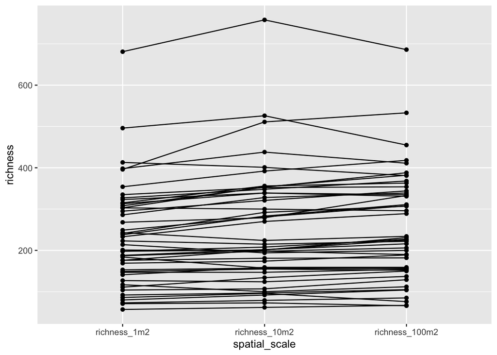

```r
library(ggplot2)
n_all$paired = rep(c(1:47),times = 3)
ggplot(n_all, aes(x = spatial_scale, y = richness)) +
  geom_point() +
  geom_line(aes(group = paired))
```